# **Kieran Canter - Project 3**

## Part 1: Regression Analysis

### Exercise 1

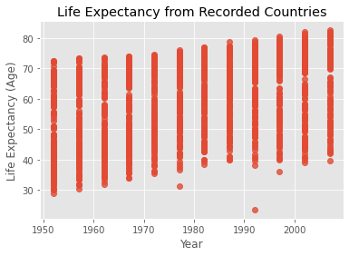

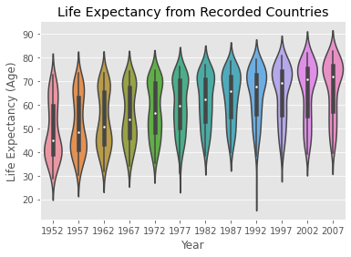

```python
import pandas as pd
import matplotlib.pyplot as plt
import seaborn as sns
import numpy as np
from sklearn.linear_model import LinearRegression as lr
from sklearn.preprocessing import PolynomialFeatures as pf
plt.style.use('ggplot')

df_gap = pd.read_csv("mirror/08_gap-every-five-years.tsv", sep='\t')

regplot_life_expectancy_nofit = sns.regplot(data=df_gap, x="year", y="lifeExp", fit_reg=False)
regplot_life_expectancy_nofit.set(xlabel = "Year", ylabel = "Life Expectancy (Age)", title = "Life Expectancy from Recorded Countries");
plt.show()

vioplot_life_expectancy = sns.violinplot(data=df_gap, x="year", y="lifeExp")
vioplot_life_expectancy.set(xlabel = "Year", ylabel = "Life Expectancy (Age)", title = "Life Expectancy from Recorded Countries");
plt.show()
```

### Question 1

The general trend of the for the overall life expectancy appears to be increasing. From the data points, the trend appears to linearly increase over the ~55 years.

### Question 2

Some of the life expectancy distributions across countries appear to be skewed while others seem balanced. The first couple violins (left side) seem to be skewed towards the bottom while the final six or so violins are skewed towards the top. From years 1962-1977, the violins are fairly balanced. Similarly, the majority of the violins appear to be unimodal while the more balanced violins specified earlier appearing to be bimodal. The plot is not symmetric around its center as it linearly increases from one side to the other.

### Question 3

I would not reject the null hypothesis simply from seeing the linear regression model fit because there would not be enough evidence to substantiate that the null hypothesis is incorrect.

### Question 4

A violin plot of residuals for the previously mentioned linear regression model would probably appear to have similarly shaped violins as the plot constructed above, but since residuals measure the predicted values vs. the actual values, the violins would appear to be more in line than increasing.

### Question 5

I think the violin plot should look as I described above. Assumptions commonly associated with linear regression models are:

- The relationship between x and y is linear.
- The variance of residual for any value of x is the same.
- Observations are independent of each other.
- For any fixed value of x, y is normally distributed.

With these in mind, I believe the violin plot of residuals should look as I described above in Question 4.

### Exercise 2

```
The fitted model is y = 0.326x - 585.652.
```

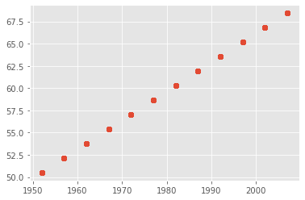

```python
x = df_gap["year"].values.reshape(len(df_gap["year"]), 1)
y = df_gap["lifeExp"].values.reshape(len(df_gap["lifeExp"]), 1)

reg = lr().fit(x, y)
plt.scatter(x, reg.predict(x))
print(f"The fitted model is y = {reg.coef_[0][0]:.3f}x - {reg.intercept_[0]*-1:.3f}.")
```

### Question 6

On average, the life expectancy increases by about 0.326 years every year.

### Question 7

After finding a linear regression model for the data, the null hypothesis that the variables contain no correlation can be rejected because the slope is not 0 or close to 0 (relative to the range in y values).

### Exercise 3

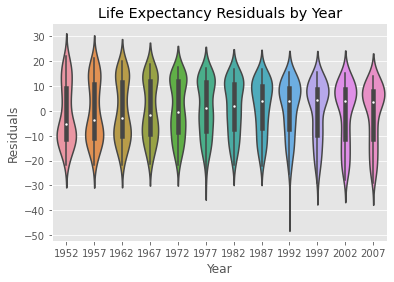

```python
predicted_values = reg.predict(x)
#print(df_gap["lifeExp"].to_numpy() - predicted_values)

df_residuals = pd.DataFrame()
df_residuals["lifeExp"] = df_gap["lifeExp"]
df_residuals["year"] = df_gap["year"]
df_residuals["pred_val"] = predicted_values
df_residuals["residuals"] = df_residuals["lifeExp"] - df_residuals["pred_val"]

vioplot_res = sns.violinplot(data=df_residuals, x="year", y="residuals")
vioplot_res.set(xlabel = "Year", ylabel = "Residuals", title = "Life Expectancy Residuals by Year");
plt.show()
```

### Question 8

The plot does meet my expectations; however, I expected the medians to be a little bit more in line with each other.

### Exercise 4

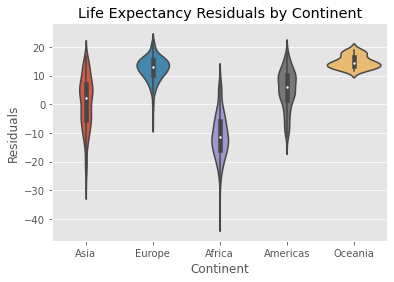

```python
df_residuals["country"] = df_gap["country"]
df_residuals["continent"] = df_gap["continent"]

vioplot_res_continent = sns.violinplot(data=df_residuals, x="continent", y="residuals")
vioplot_res_continent.set(xlabel = "Continent", ylabel = "Residuals", title = "Life Expectancy Residuals by Continent");
plt.show()
```

### Question 9

There appears to be strong correlations between model residuals and continent. For example, Europe and Oceania have significantly larger and more concentrated distributions while Africa has a long, stretched distribution that is centered much lower. This suggests that the regression analysis conducted on the gross data cannot be as accurate and reliable as separate regression analyses done on the data by continent.

### Exercise 5

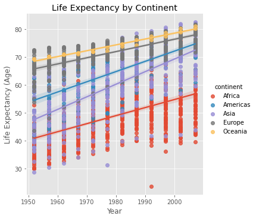

```python
df_gap_bycontinent = df_gap.sort_values(by=["continent"], ignore_index=True)

regplot_bycontinent = sns.lmplot(data=df_gap_bycontinent, x="year", y="lifeExp", hue="continent")
regplot_bycontinent.set(xlabel = "Year", ylabel = "Life Expectancy (Age)", title = "Life Expectancy by Continent");
plt.show()
```

### Question 10

The regression model should include an interaction term for continent and year because as can be seen from the above plot, the best fit lines differ greatly by continent, so we get an over-generalized and over-averaged model when we include them all in the same data set.

### Exercise 6

**could not complete**

### Question 11

**could not complete**

### Question 12

**could not complete**

### Exercise 7

**could not complete**

## Part 2: Classification

:(